# Seeds

Aya AMENSSAG

3/16/2022

# Préparation des données :

```r
"N" <- 21
"r" <- c(10, 23, 23, 26, 17, 5, 53, 55, 32, 46, 10, 8, 10, 8, 23, 0, 3, 22, 15, 32, 3)
"n" <- c(39, 62, 81, 51, 39, 6, 74, 72, 51, 79, 13, 16, 30, 28, 45,  4, 12, 41, 30, 51, 7)
"x1" <- c(0, 0, 0, 0, 0, 0, 0, 0, 0, 0, 0, 1, 1, 1, 1, 1, 1, 1, 1, 1, 1)
"x2" <- c(0, 0, 0, 0, 0, 1, 1, 1, 1, 1, 1, 0, 0, 0, 0, 0, 1, 1, 1, 1, 1)
```

# Initialisation :

```r
init_alpha0 <- 0
init_alpha1 <- 0
init_alpha2 <- 0
init_alpha12 <- 0
init_sigma <- 1/10
init_b <- c(0, 0, 0, 0, 0, 0, 0, 0, 0, 0, 0, 0, 0, 0, 0, 0, 0, 0, 0, 0, 0)
```

# Importation des packages:

```r
library(boot)
library(coda)
library(factoextra)
```

# Échantillonneur Hastings-within-Gibbs :

```r
seeds <- function(nchain, init_alpha0, init_alpha1, init_alpha2, init_alpha12, init_sigma, init_b, prop_sd, x1, x2, N)
{

  alpha0 <- init_alpha0
  alpha1 <- init_alpha1
  alpha2 <- init_alpha2
  alpha12 <- init_alpha12
  sigma <- init_sigma
  b <- init_b

  p <- plogis(alpha0 + alpha1 * x1 + alpha2 * x2 + alpha12 * x1 * x2 + b)

  chain <- matrix(NA, nchain + 1, 5)
  chain_b <- matrix(NA, nchain + 1, N)

  chain[1,1] <- init_alpha0
  chain[1,2] <- init_alpha1
  chain[1,3] <- init_alpha2
  chain[1,4] <- init_alpha12
  chain[1,5] <- init_sigma
  chain_b[1,] <- init_b

  acc_rates <- rep(0,4)

  for (i in 1:nchain)
  {
    # Mise à jour de alpha0
    prop <- rnorm(1, alpha0, prop_sd[1])
    prop_p <- plogis(prop + alpha1 * x1 + alpha2 * x2 + alpha12 * x1 * x2 + b)

    top <- - ((prop^2) / (2 * 1e6)) + sum(r * log(prop_p)) + sum((n-r) * log(1 - prop_p))
    bottom <- - ((alpha0^2) / (2 * 1e6)) + sum(r * log(p)) + sum((n-r) * log(1 - p))

    acc_prob <- exp(top - bottom)

    if (runif(1) < acc_prob){
      alpha0 <- prop
      p <- prop_p
      acc_rates[1] <- acc_rates[1]+1
    }

    # Mise à jour de alpha1
    prop <- rnorm(1, alpha1, prop_sd[2])
    prop_p <- plogis(alpha0 + prop * x1 + alpha2 * x2 + alpha12 * x1 * x2 + b)

    top <- - ((prop^2) / (2 * 1e6)) + sum(r * log(prop_p)) + sum((n-r) * log(1 - prop_p))
    bottom <- - ((alpha1^2) / (2 * 1e6)) + sum(r * log(p)) + sum((n-r) * log(1 - p))

    acc_prob <- exp(top - bottom)

    if (runif(1) < acc_prob){
      alpha1 <- prop
      p <- prop_p
      acc_rates[2] <- acc_rates[2]+1
    }

    # Mise à jour de alpha2
    prop <- rnorm(1, alpha2, prop_sd[3])
    prop_p <- plogis(alpha0 + alpha1 * x1 + prop * x2 + alpha12 * x1 * x2 + b)

    top <- - ((prop^2) / (2 * 1e6)) + sum(r * log(prop_p)) + sum((n-r) * log(1 - prop_p))
    bottom <- - ((alpha2^2) / (2 * 1e6)) + sum(r * log(p)) + sum((n-r) * log(1 - p))

    acc_prob <- exp(top - bottom)

    if (runif(1) < acc_prob){
      alpha2 <- prop
      p <- prop_p
      acc_rates[3] <- acc_rates[3]+1
    }

    # Mise à jour de alpha12
    prop <- rnorm(1, alpha12, prop_sd[4])
    prop_p <- plogis(alpha0 + alpha1 * x1 + alpha2 * x2 + prop * x1 * x2 + b)

    top <- - ((prop^2) / (2 * 1e6)) + sum(r * log(prop_p)) + sum((n-r) * log(1 - prop_p))
    bottom <- - ((alpha12^2) / (2 * 1e6)) + sum(r * log(p)) + sum((n-r) * log(1 - p))

    acc_prob <- exp(top - bottom)

    if (runif(1) < acc_prob){
      alpha12 <- prop
      p <- prop_p
      acc_rates[4] <- acc_rates[4]+1
    }

    # Mise à jour de sigma
    sigma <- 1 / rgamma(1, shape = 10e-3 + N / 2, scale = 1e-3 + 0.5 * sum(b^2)) #change parameters

    # Mise à jour de b
    for (j in 1:N)
    {
      prop <- rnorm(1, b[j], prop_sd[5])
      prop_p_j <- plogis(alpha0 + alpha1 * x1[j] + alpha2 * x2[j] + alpha12 * x1[j] * x2[j] + prop)

      top <- - (prop^2 / (2 * sigma)) + r[j] * log(prop_p_j) + (n[j] - r[j]) * log(1 - prop_p_j)
      bottom <- - (b[j]^2 / (2 * sigma)) + r[j] * log(p[j]) + (n[j] - r[j]) * log(1 - p[j])

      acc_prob <- exp(top - bottom)

      if (runif(1) < acc_prob){
        b[j] <- prop
        p[j] <- prop_p_j
      }
    }
    #Mise à jour de la chaine
    chain[i+1,] <- c(alpha0, alpha1, alpha2, alpha12, sigma)
    chain_b[i+1,] <- b
  }
  my_list <- list("chain" = chain, "b_chain" = chain_b, "acc_rates" = acc_rates)
  return(my_list)
}
```

```r
l <- seeds(1e4, init_alpha0, init_alpha1, init_alpha2, init_alpha12, init_sigma, init_b, prop_sd = c(0.25, 0.5, 0.3, 0.5, 0.3), x1, x2, N)
```

# Résultat :

## $\alpha_0$

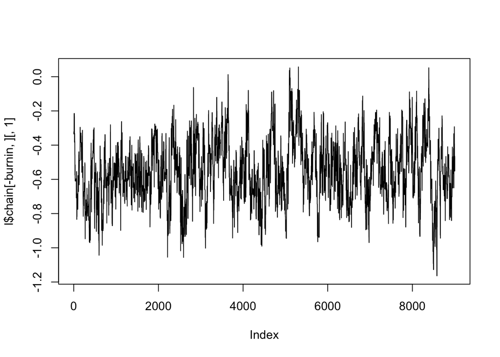

```r
burnin <- (1:1000)
plot(l$chain[-burnin,][,1], type = "l", main = "")
```

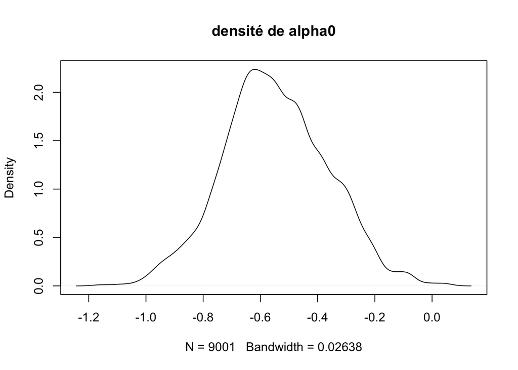

```r
plot(density(l$chain[-burnin,][,1]), type = "l", main = "densité de alpha0")
```

```r
sprintf("Le taux d'acceptation de alpha0 : %s", l$acc_rates[1]/100)
```

```
## [1] "Le taux d'acceptation de alpha0 : 34.03"
```

```r
mean_alpha0 = mean(l$chain[,1])
sprintf("La moyenne empirique de alpha0 : %s", mean_alpha0)
```

```
## [1] "La moyenne empirique de alpha0 : -0.547400821613915"
```

```r
sd_alpha0 = sd(l$chain[,1])
sprintf("L'écart-type empirique de alpha0 : %s", sd_alpha0)
```

```
## [1] "L'écart-type empirique de alpha0 : 0.185914556625516"
```

## $\alpha_1$

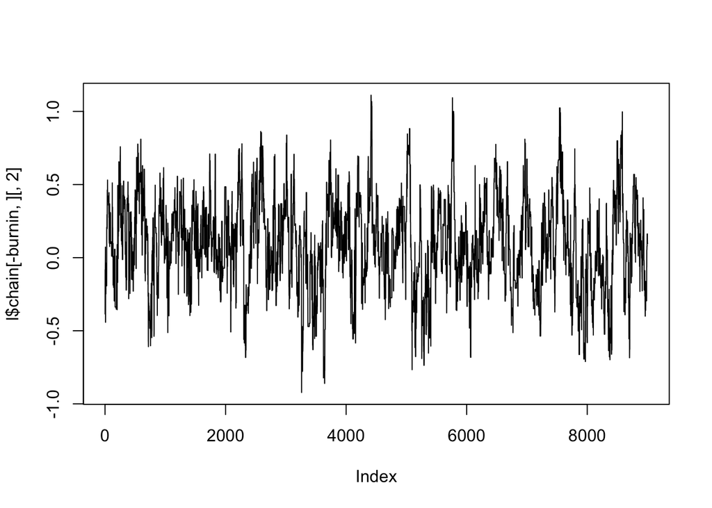

```r
plot(l$chain[-burnin,][,2], type = "l", main = "")
```

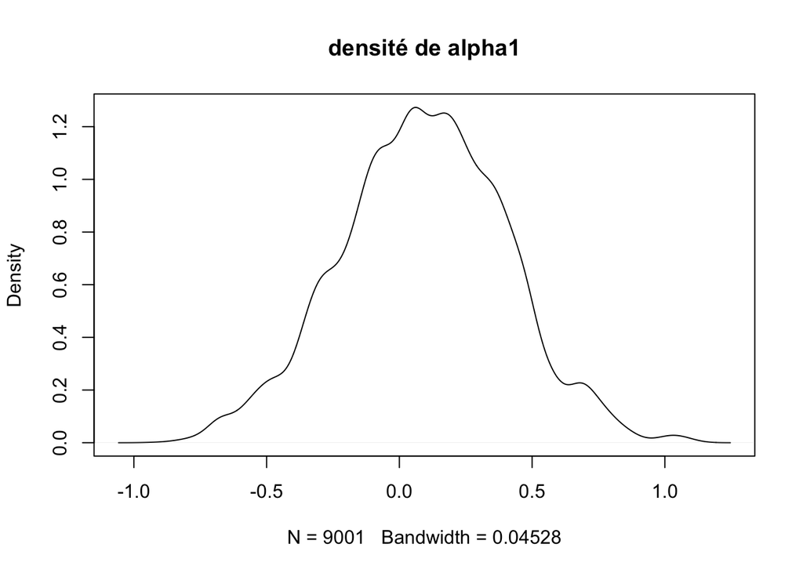

```r
plot(density(l$chain[-burnin,][,2]), type = "l", main = "densité de alpha1")
```

```r
sprintf("Le taux d'acceptation de alpha1 : %s", l$acc_rates[2]/100)
```

```
## [1] "Le taux d'acceptation de alpha1 : 29.63"
```

```r
mean_alpha1 = mean(l$chain[,2])
sprintf("La moyenne empirique de alpha1 : %s", mean_alpha1)
```

```
## [1] "La moyenne empirique de alpha1 : 0.0887141674322909"
```

```r
sd_alpha1 = sd(l$chain[,2])
sprintf("L'écart-type empirique de alpha1 : %s", sd_alpha1)
```

```
## [1] "L'écart-type empirique de alpha1 : 0.311547652269039"
```

## $\alpha_2$

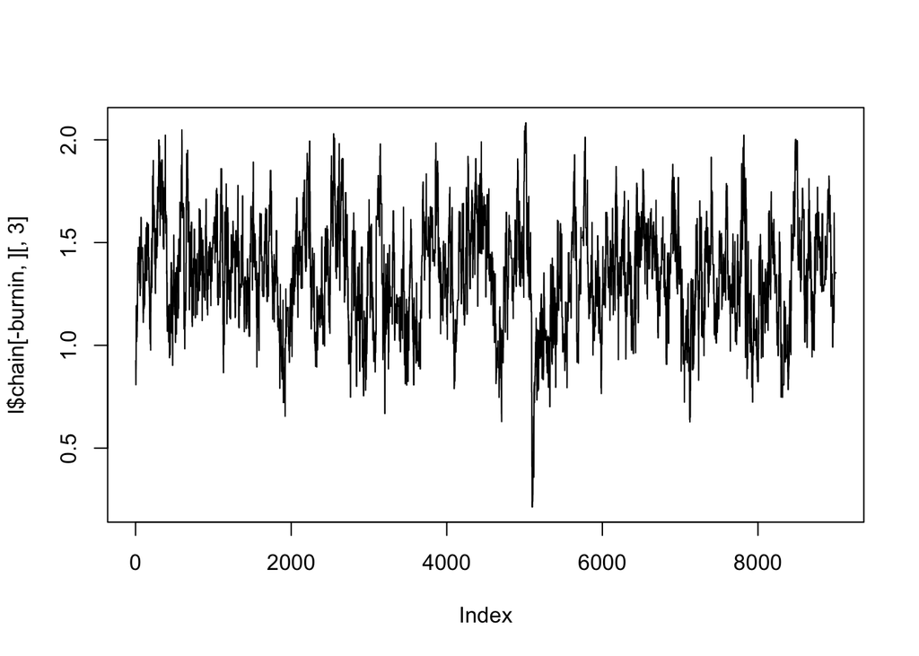

```r
plot(l$chain[-burnin,][,3], type = "l", main = "")
```

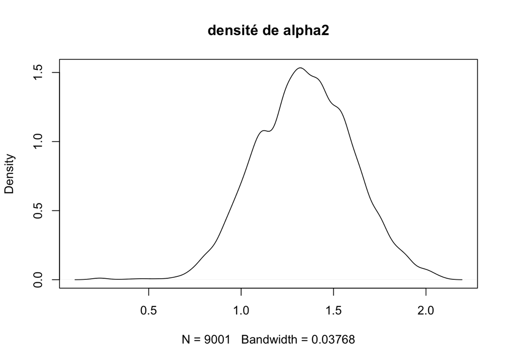

```r
plot(density(l$chain[-burnin,][,3]), type = "l", main = "densité de alpha2")
```

```r
sprintf("Le taux d'acceptation de alpha2 : %s", l$acc_rates[3]/100)
```

```
## [1] "Le taux d'acceptation de alpha2 : 37.51"
```

```r
mean_alpha2 = mean(l$chain[,3])
sprintf("La moyenne empirique de alpha2 : %s", mean_alpha2)
```

```
## [1] "La moyenne empirique de alpha2 : 1.34399510972094"
```

```r
sd_alpha2 = sd(l$chain[,3])
sprintf("L'écart-type empirique de alpha2 : %s", sd_alpha2)
```

```
## [1] "L'écart-type empirique de alpha2 : 0.263774152124048"
```

## $\alpha_{12}$

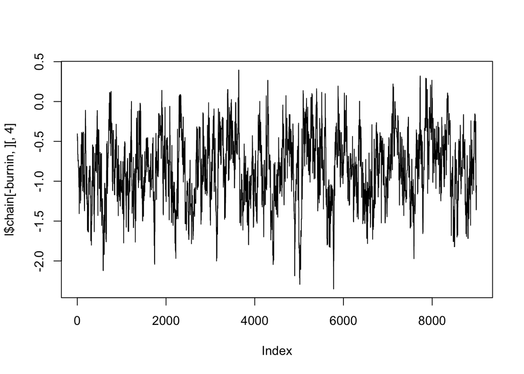

```r
plot(l$chain[-burnin,][,4], type = "l", main = "")
```

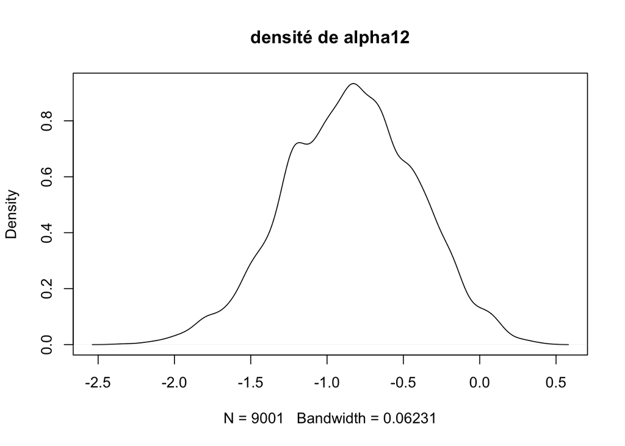

```r
plot(density(l$chain[-burnin,][,4]), type = "l", main = "densité de alpha12")
```

```r
sprintf("Le taux d'acceptation de alpha12 : %s", l$acc_rates[4]/100)
```

```
## [1] "Le taux d'acceptation de alpha12 : 37.33"
```

```r
mean_alpha12 = mean(l$chain[,4])
sprintf("La moyenne empirique de alpha12 : %s", mean_alpha12)
```

```
## [1] "La moyenne empirique de alpha12 : -0.839776457114234"
```

```r
sd_alpha12 = sd(l$chain[,4])
sprintf("L'écart-type empirique de alpha12 : %s", sd_alpha12)
```

```
## [1] "L'écart-type empirique de alpha12 : 0.428683417583903"
```

## $\sigma$

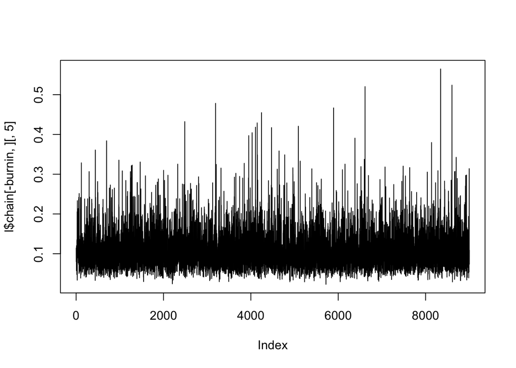

```r
plot(l$chain[-burnin,][,5], type = "l", main = "")
```

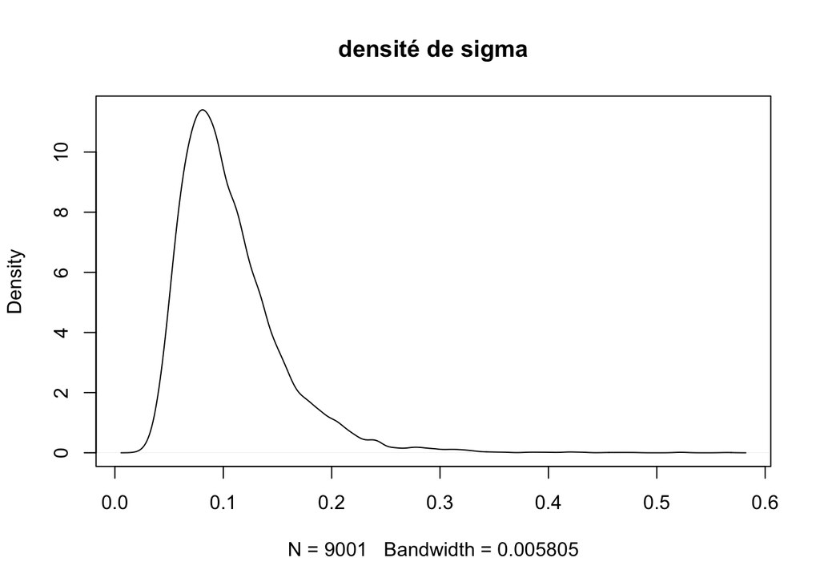

```r
plot(density(l$chain[-burnin,][,5]), type = "l", main = "densité de sigma")
```

```r
mean_sigma = mean(sqrt(l$chain[,5]))
sprintf("La moyenne empirique de sigma : %s", mean_sigma)
```

```
## [1] "La moyenne empirique de sigma : 0.320225032896691"
```

```r
sd_sigma = sd(sqrt(l$chain[,5]))
sprintf("L'écart-type empirique de sigma : %s", sd_sigma)
```

```
## [1] "L'écart-type empirique de sigma : 0.123988577337397"
```

Les moyennes et les écarts-types que nous obtenons sont relativement proches de ceux proposés par l’énoncé.

# Tous les résultats dans un graphe

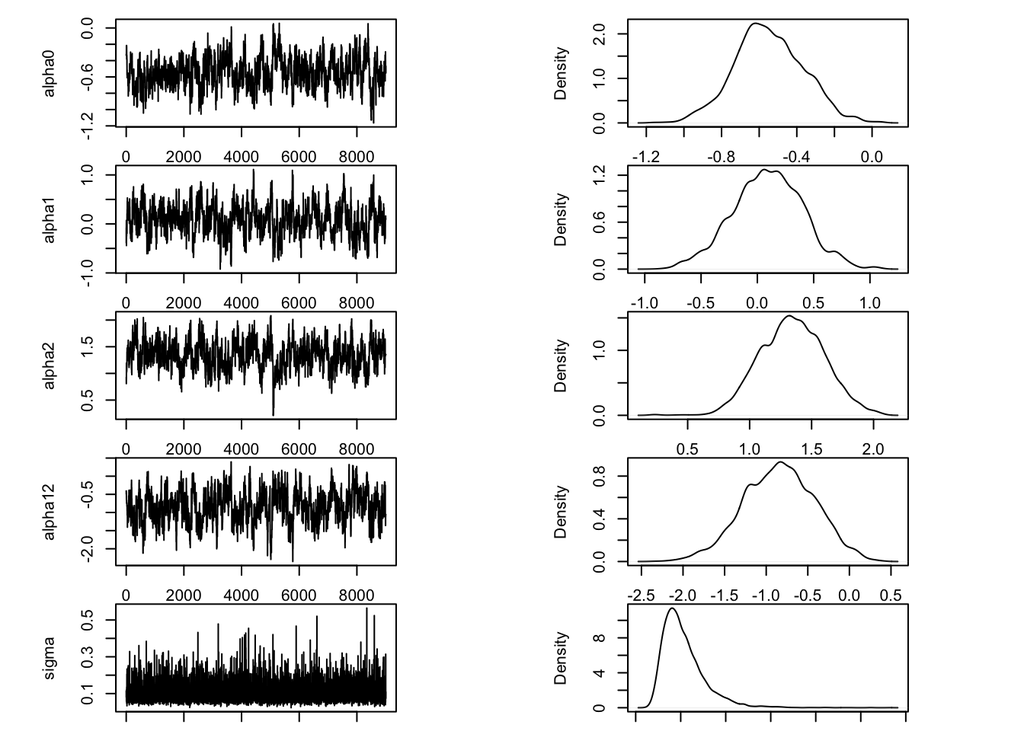

```r
text=c("alpha0", "alpha1", "alpha2", "alpha12", "sigma")
par(mfrow = c(5, 2), mar = c(1, 6, 1, 6))
for (j in 1:5){
  plot(l$chain[-burnin,][,j], type = "l", main = "",ylab=text[j])
  plot(density(l$chain[-burnin,][,j]), type = "l", main = "")
}
```

## Quelques valeurs de $b$

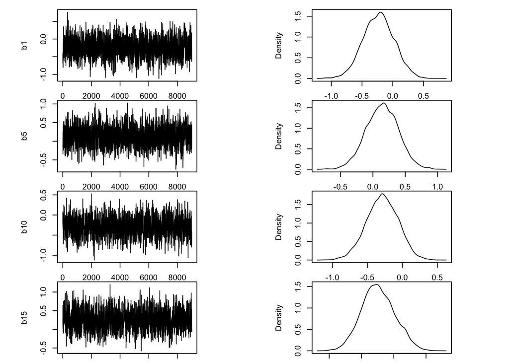

```r
text=c("b1", "b5", "b10", "b15")
val = c(1,5,10,15)
par(mfrow = c(4, 2), mar = c(1, 6, 1, 6))
for (j in 1:4){
  plot(l$b_chain[-burnin,][,val[j]], type = "l", main = "",ylab=text[j])
  plot(density(l$b_chain[-burnin,][,val[j]]), type = "l", main = "")
}
```

Les chaînes de $b$ se comportent normalement.

# Inteprétation

En utilisant les moyennes obtenues précédemment, on essaie de visualiser l’impact de $x_1$ et $x_2$ sur $\operatorname{logit}(p)$:

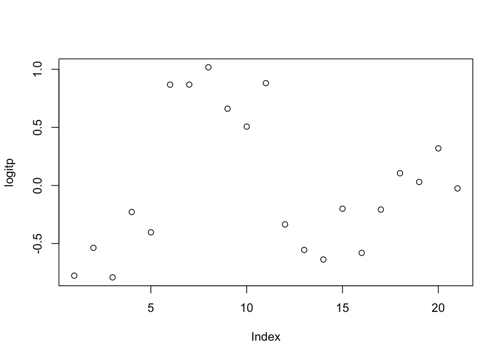

```r
mean_b = c(mean(l$b_chain[,1]))
for (i in 2:21){
  mean_b <- append(mean_b, mean(l$b_chain[,i]))
}
logitp = mean_alpha0 + mean_alpha1 * x1 + mean_alpha2 * x2 + mean_alpha12 * x1 * x2 + mean_b
plot(logitp)
```

Après avoir tracé $\operatorname{logit}(p)$ en fonction de l’indice, on constate qu’il y a des clusters qu’on va essayer de visualiser plus clairement en effectuant un k-means clustering:

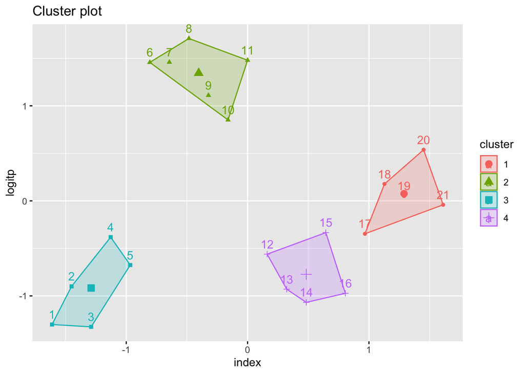

```r
index <- 1:21
df <- data.frame(index, logitp)
res_kmeans <- kmeans(df, centers = 4 , nstart = 1000)
fviz_cluster(res_kmeans, data = df)
```

```r
c1 = which(res_kmeans$cluster==1)
c2 = which(res_kmeans$cluster==2)
c3 = which(res_kmeans$cluster==3)
c4 = which(res_kmeans$cluster==4)
```

```r
x <- x1*x2
x[c1]
```

```
## [1] 1 1 1 1 1
```

```r
x[c2]
```

```
## [1] 0 0 0 0 0 0
```

```r
x[c3]
```

```
## [1] 0 0 0 0 0
```

```r
x[c4]
```

```
## [1] 0 0 0 0 0
```

```r
x1[c1]
```

```
## [1] 1 1 1 1 1
```

```r
x1[c2]
```

```
## [1] 0 0 0 0 0 0
```

```r
x1[c3]
```

```
## [1] 0 0 0 0 0
```

```r
x1[c4]
```

```
## [1] 1 1 1 1 1
```

```r
x2[c1]
```

```
## [1] 1 1 1 1 1
```

```r
x2[c2]
```

```
## [1] 1 1 1 1 1 1
```

```r
x2[c3]
```

```
## [1] 0 0 0 0 0
```

```r
x2[c4]
```

```
## [1] 0 0 0 0 0
```

Cela signifie qu’une graine *cucumber* a beaucoup plus de chances de germer lorsque le type de graine est *aegyptiao 75*, alors qu’une graine *bean* a légèrement plus de chances de germer lorsque le type de graine est *aegyptiao 73*, mais ce n’est pas drastique comparé à une graine *cucumber*.